# Biostatistical Computing, PHC 6068

Clustering algorithm

Zhiguang Huo (Caleb)

Wednesday October 17, 2018

# Outlines

- Unsupervised machine learning
  - $k$-means Clustering algorithm
  - Hierarchical Clustering algorithm (may not have enough time to cover this one)

# Unsupervised machine learning

- Unsupervised machine learning (a.k.a. cluster analysis) is a set of methods to assign objects into clusters when class labels are unknown.

[figure not shown]

https://cdn-images-1.medium.com/max/1600/1*6hfFWPITJxbtw4ztoC1YeA.png

# Motivating example in R

- How to cluster the following data?

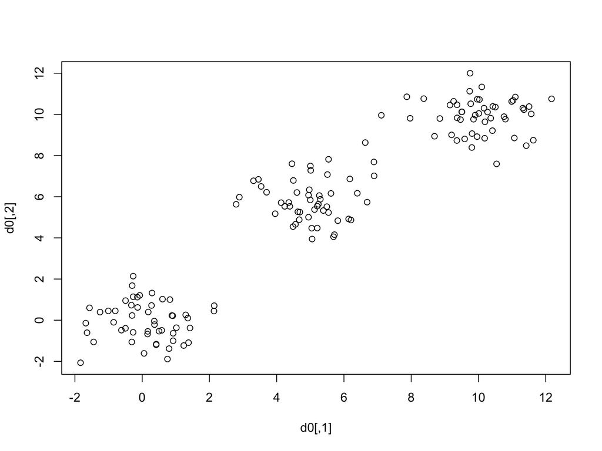

```r
library(MASS)
set.seed(32611)
a<- mvrnorm(50, c(0,0), matrix(c(1,0,0,1),2))
b<- mvrnorm(50, c(5,6), matrix(c(1,0,0,1),2))
c<- mvrnorm(50, c(10,10), matrix(c(1,0,0,1),2))
d0 <- rbind(a,b,c)
plot(d0)
```

# Motivating example in R (applying kmeans)

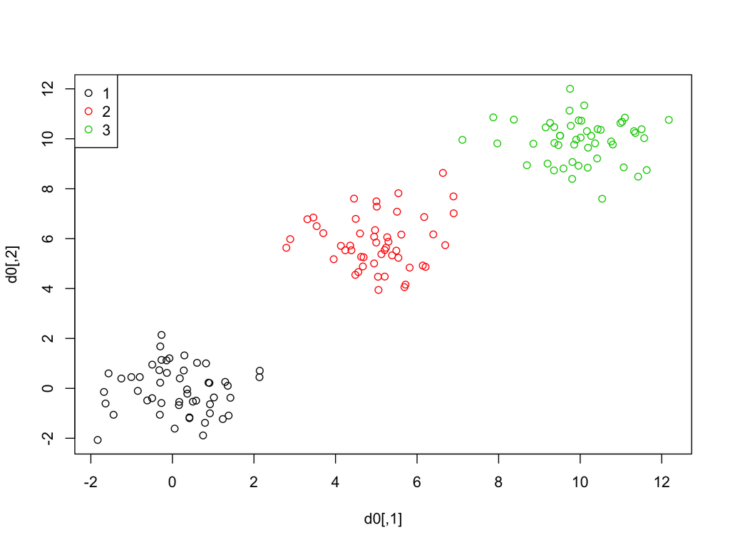

```r
set.seed(32611)
result_km <- kmeans(d0, centers = 3)
plot(d0, col=result_km$cluster)
legend("topleft", legend = 1:3, col = 1:3, pch=1)
```

# $k$-means

- Objective function:
  - Minimize the within-cluster dispersion to the cluster centers.
- Pre-specify number of clusters $K$

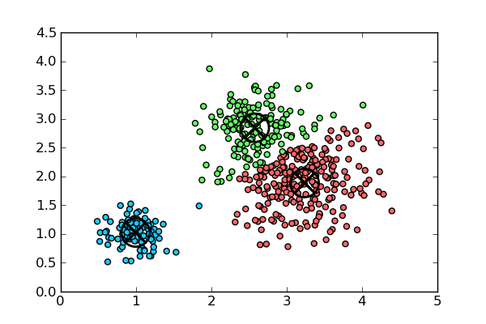

# $k$-means objective function

$$\min_C \sum_{k=1}^K \sum_{i \in C_k} \|x_i - \bar{x}_{C_k}\|^2,$$

- $i$ is a sample index.
- $K$ is total number of clusters.
- $x_i \in \mathbb{R}^p$ is a $p$-dimensional vector.
- $C_k$ is a collection of samples belong to cluster $k$
- $\bar{x}_{C_K}$ is the cluster center of $C_K$.
  - $\bar{x}_{C_k} = \frac{1}{|C_k|} \sum_{i\in C_k} x_i$
  - $|C_k|$ is number of samples in cluster $k$
- $C = (C_1, \ldots, C_K)$

# $k$-means algorithm

1. Initialize $K$ centers $c_1, \ldots, c_K$ as starting values.
2. (Updating clustering labels) Form the clusters $C_1, \ldots, C_K$ as follows.
   - Denote the clustering labels for subject $i$: $g_i = \arg \min_k \|x_i - c_k\|^2$.
   - $C_k = \{i: g_i = k\}$
3. (Updating clustering centers) For $k = 1, \ldots, K$, set the $k^{th}$ clustering center of $c_k$ as:
   $$c_k \rightarrow \frac{1}{|C_k|} \sum_{i\in C_k} x_i$$
4. Repeat 2 and 3 until converge
5. Output: centers $c_1, \ldots, c_K$ and clusters $C_1, \ldots, C_K$.

# $k$-means 2-dimensional example

- example data

```r
set.seed(32611)
N<-100
d1<-mvrnorm(N, c(0,3), matrix(c(2, 1, 1, 2), 2, 2))
d2<-mvrnorm(N, c(-2,-2), matrix(c(2, 1, 1, 2), 2, 2))
d3<-mvrnorm(N, c(2,-2), matrix(c(2, 1, 1, 2), 2, 2))
d <- rbind(d1, d2, d3)
colnames(d) <- c("x", "y")
label <- c(rep("1", N), rep("2", N), rep("3", N))
```

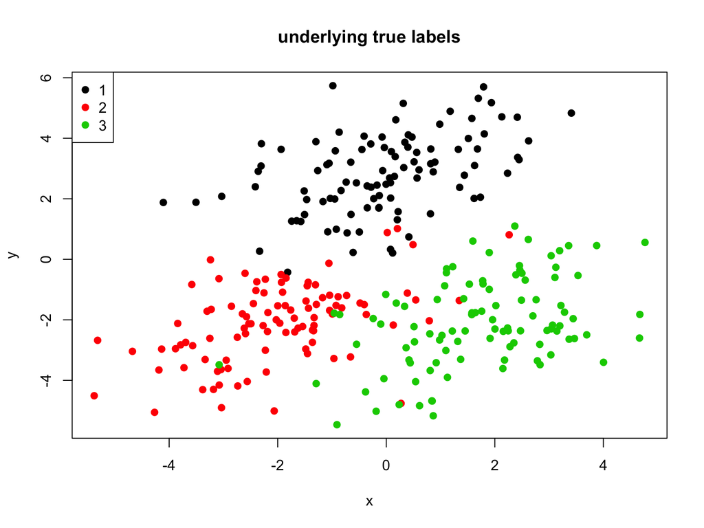

```r
plot(d, pch = 19, col=as.numeric(label), main = "underlying true labels")
legend("topleft", legend = unique(label), col=unique(as.numeric(label)), pch=19)
```

# $k$-means demonstration

```r
K <- 3
set.seed(32611)
centers <- mvrnorm(K, mu = c(0,0), Sigma = diag(c(1,1)))
colnames(centers) <- c("x", "y")

plot(d, pch=19)
points(centers, col = 2:4, pch=9, cex=2)


l2n <- function(avec){
  return(sum(avec^2))
}

## update group labels
groupsDist <- matrix(0,nrow=nrow(d),ncol=K)
for(k in 1:K){
  vecDiff <- t(d) - centers[k,]
  al2n <- apply(vecDiff,2,l2n)
  groupsDist[,k] <- al2n
}
groups <- apply(groupsDist,1,which.min)

plot(d, pch=19, col=groups + 1)
points(centers, pch=9, cex=2)



## update centers
for(k in 1:K){
  asubset <- d[groups==k,]
  centers[k,] <- colMeans(asubset)
}

groups0 <- groups ## save the previous clustering result, in order to test convergence

plot(d, pch=19)
points(centers, col = 2:4, pch=9, cex=2)
```

[output not shown]

# Apply kmeans on the iris data example ($p>2$)

- Visualize by PCA

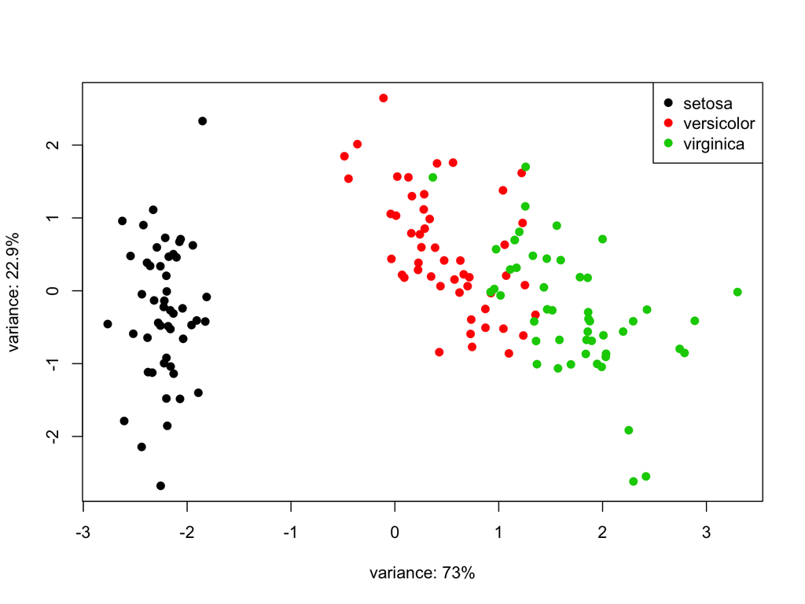

```r
iris.data <- iris[,1:4]
ir.pca <- prcomp(iris.data,
                 center = TRUE,
                 scale = TRUE)
PC1 <- ir.pca$x[,"PC1"]
PC2 <- ir.pca$x[,"PC2"]
variance <- ir.pca$sdev^2 / sum(ir.pca$sdev^2)
v1 <- paste0("variance: ",signif(variance[1] * 100,3), "%")
v2 <- paste0("variance: ",signif(variance[2] * 100,3), "%")
plot(PC1, PC2, col=as.numeric(iris$Species),pch=19, xlab=v1, ylab=v2)
legend("topright", legend = levels(iris$Species), col =  unique(iris$Species), pch = 19)
```

# Apply $k$-means on the iris data

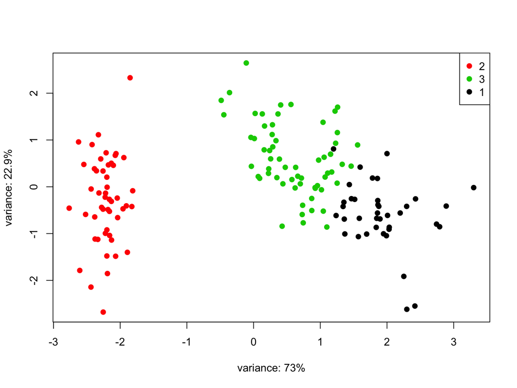

```r
set.seed(32611)
kmeans_iris <- kmeans(iris.data, 3)

plot(PC1, PC2, col=as.numeric(kmeans_iris$cluster),pch=19, xlab=v1, ylab=v2)
legend("topright", legend = unique(kmeans_iris$cluster), col =  unique(kmeans_iris$cluster), pch = 19)
```

# Put together (original lables and $k$-means labels)

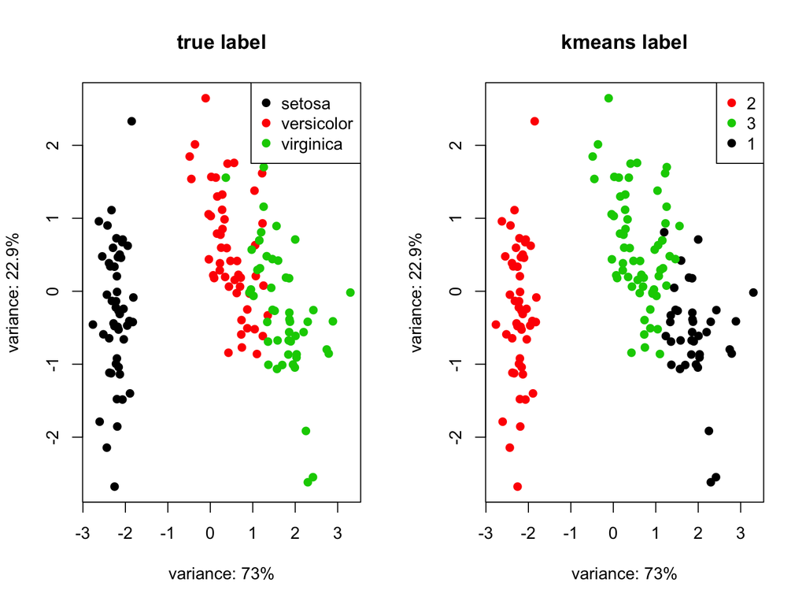

```r
par(mfrow=c(1,2))
plot(PC1, PC2, col=as.numeric(iris$Species),pch=19, xlab=v1, ylab=v2, main="true label")
legend("topright", legend = levels(iris$Species), col =  unique(iris$Species), pch = 19)

plot(PC1, PC2, col=as.numeric(kmeans_iris$cluster),pch=19, xlab=v1, ylab=v2, main="kmeans label")
legend("topright", legend = unique(kmeans_iris$cluster), col =  unique(kmeans_iris$cluster), pch = 19)
```

# Some issues about kmeans algorithm

- Is kmeans a deterministic algorithm? Or random?
- How to determine the optimal K?
- How to compare two sets of clustering results?

# Is kmeans deterministic algorithm? Or random?

- original result

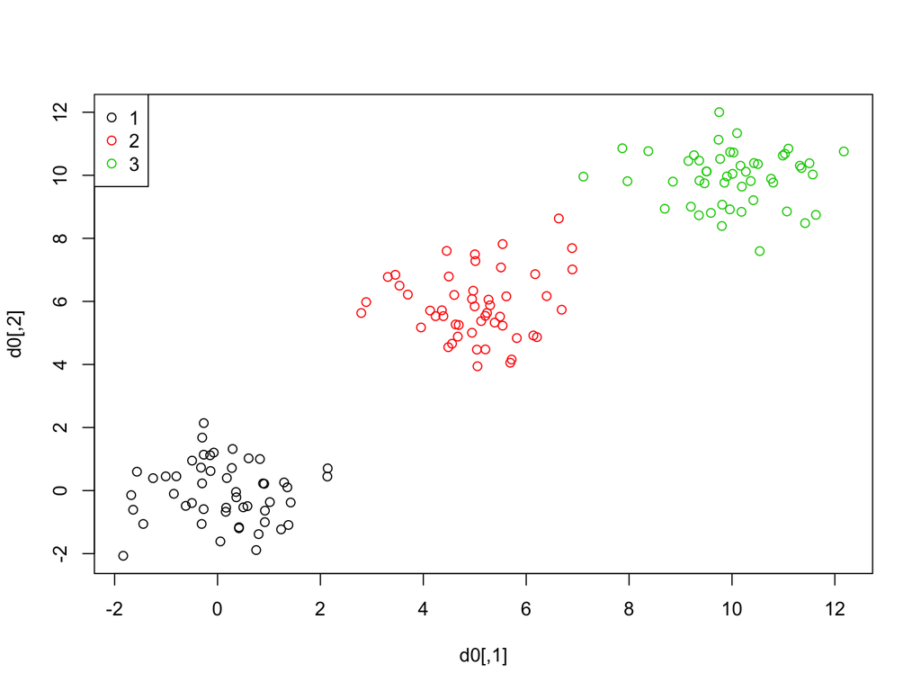

```r
set.seed(32611)
result_km <- kmeans(d0, centers = 3)
plot(d0, col=result_km$cluster)
legend("topleft", legend = 1:3, col = 1:3, pch=1)
```

- label switching

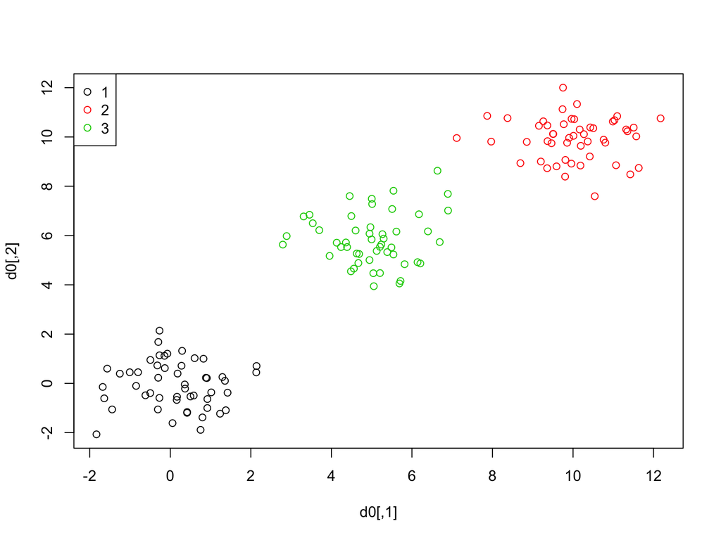

```r
set.seed(32610)
result_km <- kmeans(d0, centers = 3)
plot(d0, col=result_km$cluster)
legend("topleft", legend = 1:3, col = 1:3, pch=1)
```

- local minimum
  - can set more number of initialization to try to avoid local minimum problem

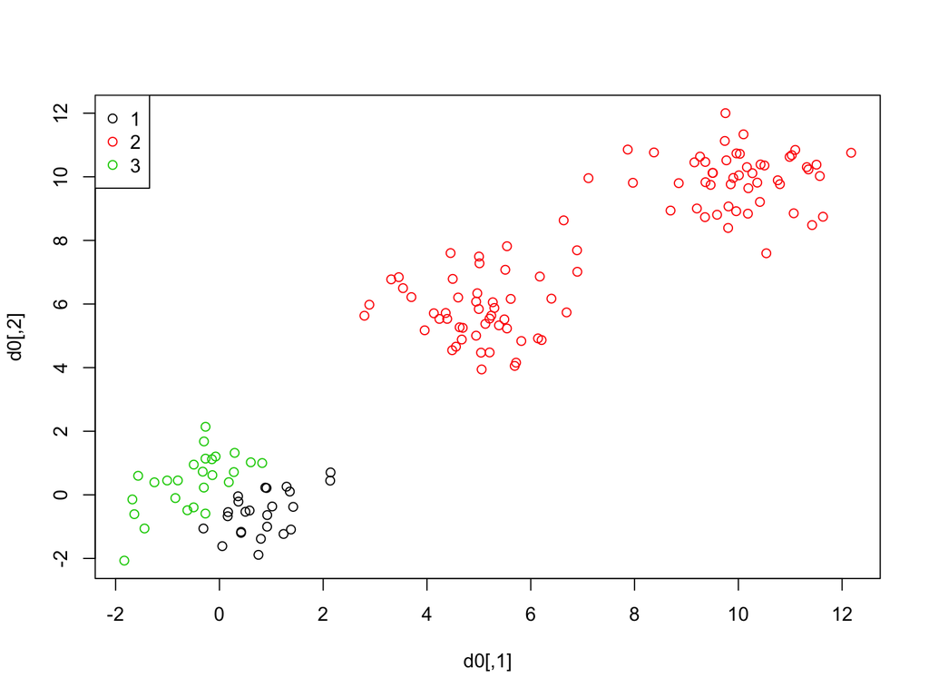

```r
set.seed(32619)
result_km <- kmeans(d0, centers = 3)
plot(d0, col=result_km$cluster)
legend("topleft", legend = 1:3, col = 1:3, pch=1)
```

# How to determine the optimal K? – Elbow method

- Within sum of squares W(k) is a decreasing function of k.
- Normally look for a turning point of elbow-shape to identify the number of clusters, k.

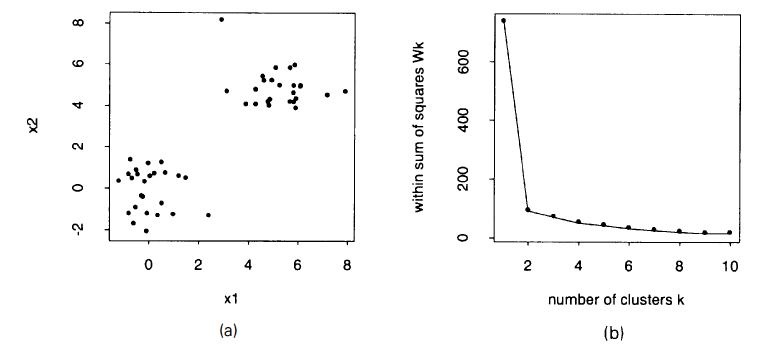

# How to determine the optimal K? – Gap statsitics

- Instead of the above arbitrary criterion, the Gap statsitics proposes to maximize the following Gap statistics.

$$\max Gap_n (k) = E_n^*(\log(W(k))) - \log(W(k))$$

- The background expectation is calculated from random sampling from the original data.

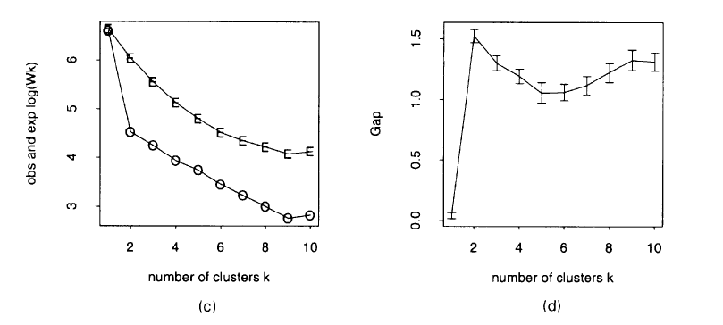

# Gap statistics

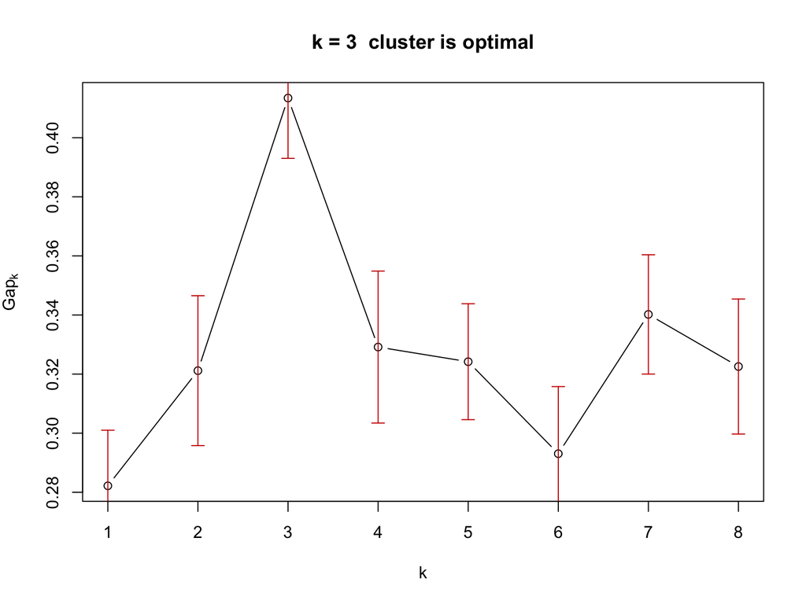

```r
library(cluster)
gsP.Z <- clusGap(d, FUN = kmeans, K.max = 8, B = 50)
plot(gsP.Z, main = "k = 3  cluster is optimal")
```

```r
gsP.Z
```

```
## Clustering Gap statistic ["clusGap"] from call:
## clusGap(x = d, FUNcluster = kmeans, K.max = 8, B = 50)
## B=50 simulated reference sets, k = 1..8; spaceH0="scaledPCA"
##  --> Number of clusters (method 'firstSEmax', SE.factor=1): 3
##          logW   E.logW       gap     SE.sim
## [1,] 5.769038 6.051226 0.2821886 0.01881499
## [2,] 5.412645 5.733809 0.3211639 0.02536302
## [3,] 5.118928 5.532351 0.4134237 0.02039893
## [4,] 5.015425 5.344578 0.3291527 0.02571314
## [5,] 4.909918 5.234112 0.3241944 0.01961303
## [6,] 4.840721 5.133776 0.2930550 0.02270741
## [7,] 4.708611 5.048810 0.3401989 0.02019276
## [8,] 4.653654 4.976211 0.3225574 0.02284422
```

# How to evaluate the clustering results?

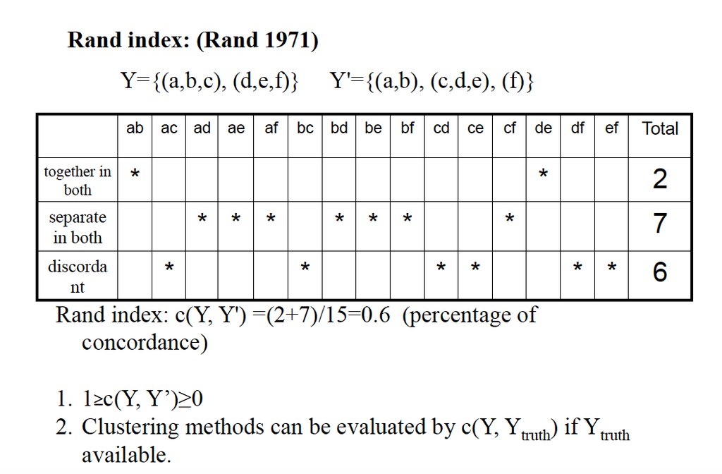

# rand index and adjusted rand index

- rand index (ranges from 0 to 1):
  - 0: poor agreement
  - 1: perfect agreement

```r
suppressMessages(library(fossil))
set.seed(32611)
g1 <- sample(1:2, size=10, replace=TRUE)
g2 <- sample(1:3, size=10, replace=TRUE)
rand.index(g1, g2)
```

```
## [1] 0.4444444
```

- adjusted rand index (ranges from -1 to 1):
  - -1: poor agreement
  - 0: the two dataset are totally independent
  - 1: perfect agreement

```r
adj.rand.index(g1, g2)
```

```
## [1] 0.1697417
```

# Hierarchical Clustering example

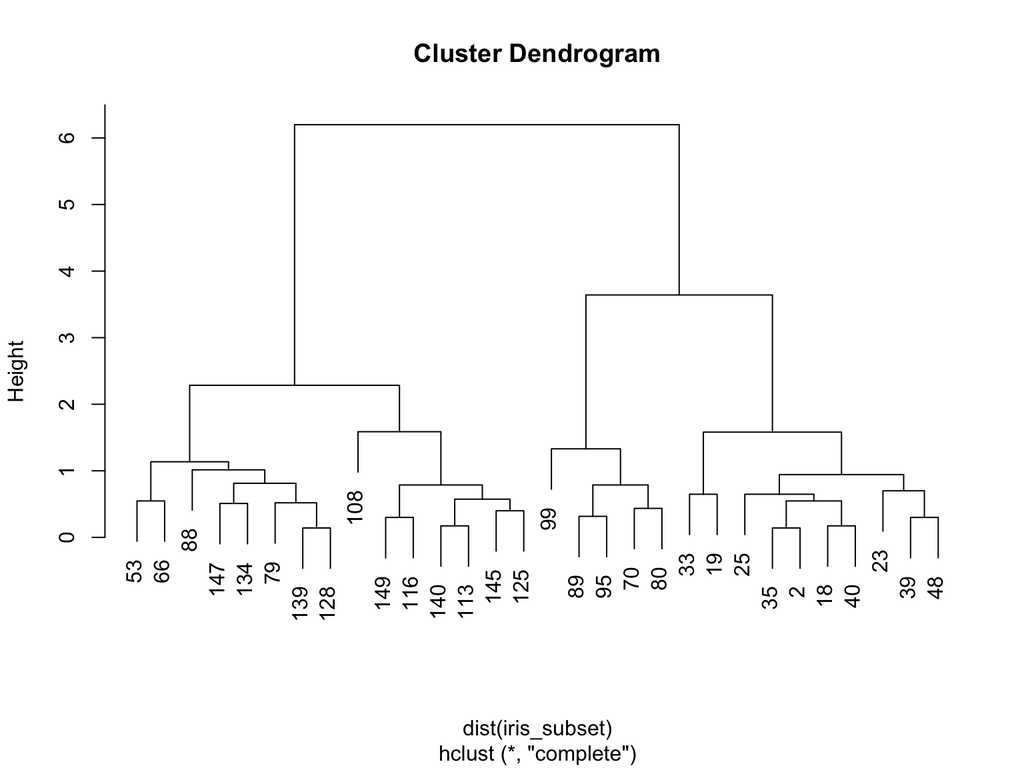

```r
set.seed(32611)
index <- sample(nrow(iris), 30)
iris_subset <- iris[index, 1:4]
species_subset <- iris$Species[index]

hc <- hclust(dist(iris_subset))
plot(hc)
```

# Hierarchical Clustering example (with color)

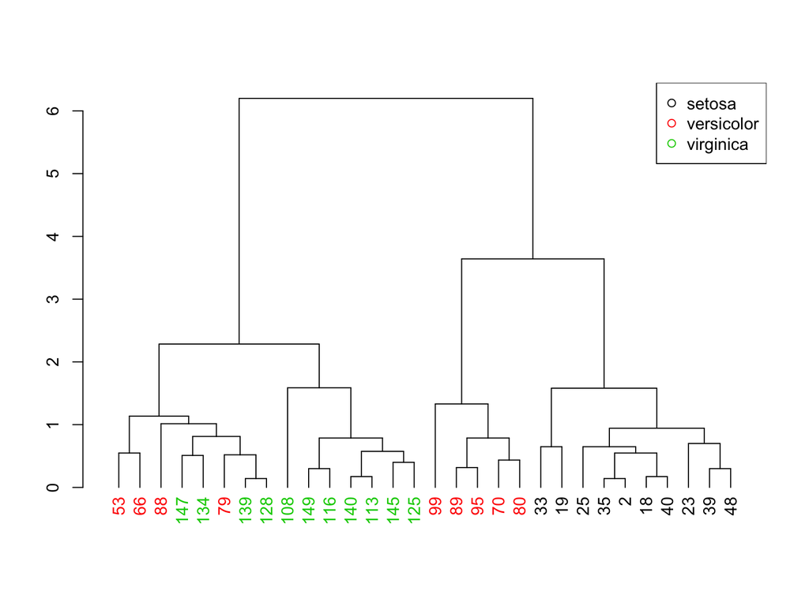

```r
suppressMessages(library(dendextend))
dend = as.dendrogram(hc)
labels_colors(dend) = as.numeric(species_subset)[order.dendrogram(dend)]

plot(dend)
legend("topright", legend=levels(species_subset), col=1:3, pch=1)
```

# $K$-means and hierarchical clustering

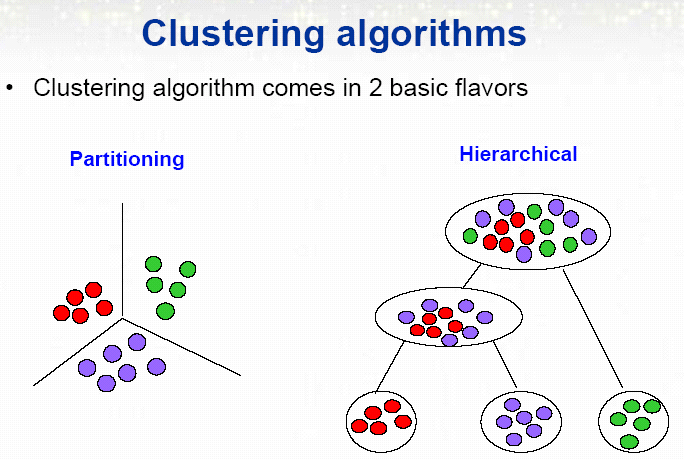

- $K$-means: Partitioning
- hierarchical clustering: Hierarchical

# Hierarchical methods

- Hierarchical clustering methods produce a **tree** or **dendrogram**.
- They avoid specifying how many clusters are appropriate by providing a partition for each $k$ obtained from cutting the tree at some level.
- The tree can be built in two distinct ways:
  - bottom-up: **agglomerative** clustering.
  - top-down: divisive clustering.

# Hierarchical clustering illustration

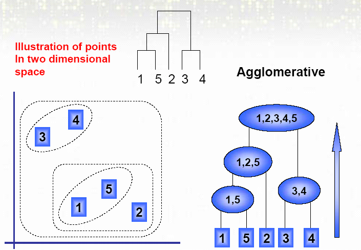

- After two data points are merged together, regard it as one single point.

# Distance between clusters

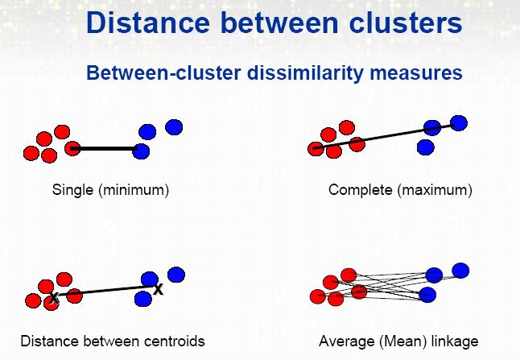

# Distance between clusters

Select a distance measurement $d$ (e.g. Euclidean distance)

- single linkage
  $$d(A, B) = \min_{x\in A, y \in B} d(x,y)$$
- average linkage
  $$d(A, B) = \frac{1}{N_AN_B}\sum_{x\in A, y \in B} d(x,y)$$
- centroid linkage
  $$d(A, B) = d(\bar{x},\bar{y}),$$
  where ${x\in A, y \in B}$
- complete linkage
  $$d(A, B) = \max_{x\in A, y \in B} d(x,y)$$

# Hierarchical tree ordering

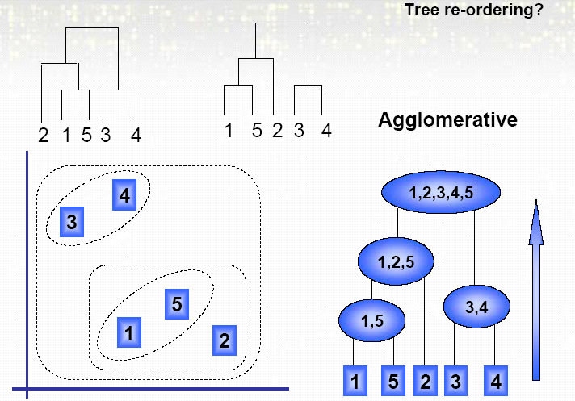

- For the same distance matrix input, the leafs position can be random.

# Hierarchical clustering algorithm

1. Input: dissimilarity matrix (distance matrix $d \in \mathbb{R}^{n \times n}$)
2. Let $T_n = \{C_1, C_2, \ldots, C_n\}$.
3. For $j = n - 1$ to $1$:
   1. Find $l,m$ to minimize $d(C_l, C_m)$ over all $C_l, C_m \in T_{j+1}$
   2. Let $T_j$ be the same as $T_{j+1}$ except that $C_l$ and $C_m$ are replaced with $C_l \cup C_m$
4. Return the sets of clusters $T_1, \ldots, T_n$
- The result can be represented as a tree, called a dendogram.
- We can then cut the tree at different places to yield any number of clusters.

# Cut Hierarchical trees

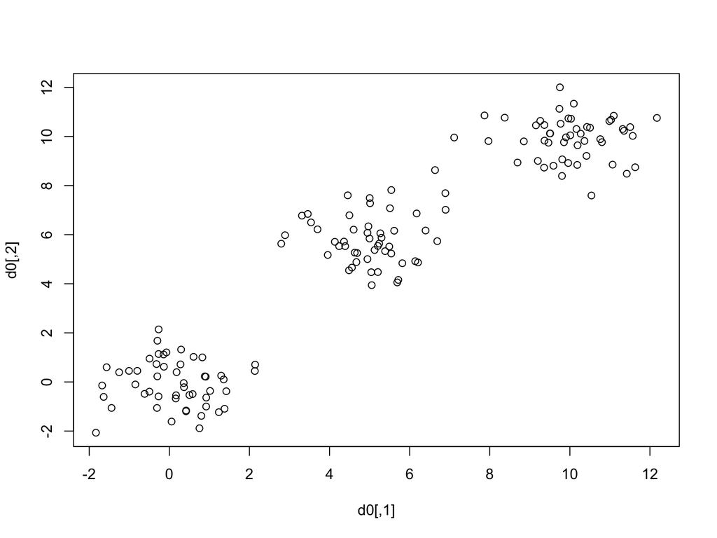

```r
plot(d0)
```

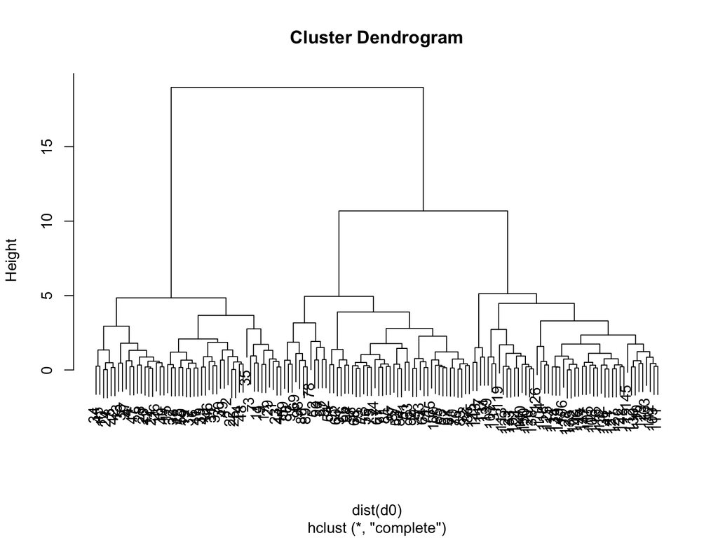

```r
hc <- hclust(dist(d0))
plot(hc)
```

```r
res_cutree <- cutree(hc, k = 1:5) #k = 1 is trivial

set.seed(32611)
result_km <- kmeans(d0, centers = 3)

table(res_cutree[,3], result_km$cluster)
```

```
##
##      1  2  3
##   1 50  0  0
##   2  0 50  0
##   3  0  0 50
```

```r
rand.index(res_cutree[,3], result_km$cluster)
```

```
## [1] 1
```

```r
adj.rand.index(res_cutree[,3], result_km$cluster)
```

```
## [1] 1
```